# Predicting Movie Earnings

```
Thomas van der Molen
S4-AI41
```

- Version History
- Introduction
- Proposal
  - Domain Understanding
    - Interview
    - Real World Example
    - Question Statement
  - Data Sourcing
  - Analytic Approach
- Iteration 1
  - Provisioning
    - Data Requirements
      - TMDb
      - The-Numbers
      - Requirements
    - Data Collection
      - Movie Bot
      - Scraper
    - Data Understanding
      - TMDb Movies
      - the-numbers Movies
    - Data Preparation
  - Predictions
    - Preprocessing
    - Modelling
    - Evaluation
- Iteration 2
  - Provisioning
    - Data Requirements
    - Data Collection
    - Data Understanding
    - Data Preparation
  - Predictions
    - Preprocessing
    - Modelling
    - Evaluation
- Delivery
  - Collecting
  - Documenting
  - Reporting

```python
%%html
<style>
table {float:left}
img {float:left}
</style>
```

## Version History

| Version | Date | Change |
| --- | --- | --- |
| 1.0 | 24-03-2022 | Created document and worked on the proposal |
| 1.1 | 25-03-2022 | Worked on proposal and provisioning |
| 1.2 | 31-03-2022 | Finished proposal and worked on provisioning |
| 1.3 | 04-04-2022 | Worked on visualization for TMDB Movies |
| 1.4 | 06-04-2022 | Worked more on visualization for TMDB Movies |
| 1.5 | 07-04-2022 | Worked more on visualization for TMDB Movies |
| 1.6 | 08-04-2022 | Finished visualization for TMDB Movies |
| 1.7 | 11-04-2022 | Worked on visualizing the-numbers and Data Preparation |
| 1.8 | 14-04-2022 | Finished Data Preperation |
| 1.9 | 20-04-2022 | Worked on Preprocessing |
| 1.10 | 21-04-2022 | Worked on Modelling |
| 1.11 | 22-04-2022 | Finished Predictions |
| 1.12 | 25-04-2022 | Started on Iteration 2 Provisioning |

## Introduction

This is iteration 1 of my challenge, if you wish to see the exploratory research done during Iteration 0, you can find that in the iteration 0 folder here or [online](https://github.com/Thomas-Molen/FHICT-S4-AI/blob/main/Challenge/Iteration0/ChallengeProposal.html)

I have decided to do a project in the domain of movies, because I enjoy watching movies and seeing what makes them succeed or fail, I have also chosen this domain because there is quite a bit of data publicly available about movies that could be used.

## Proposal

### Domain Understanding

As said in the Introduction I have chosen to do a project in the domain of movies, for this there are a couple sub domains that the film industry could be split up into. For me the most important one is the area connected to the production process, seen as the companies and individuals operating in this area put a lot of investment (both time and money) into the movie itself.

#### Interview

First step of getting a better understanding of my chosen domain would be to get into contact with domain experts.  
During Iteration 0 I looked at what companies by target audience would be for my project, in this research I found 3 different groups:

- Production and distribution (e.g. [Paramount Puctures Studios](http://www.paramountstudios.com/), [Lionsgate](https://www.lionsgate.com/))
- Financing companies (e.g. [Peacock Film Finance](https://peacockfilmfinance.com/))
- Film Bond companies (film completion bonds are a form of insurance for investors, e.g. [Surety Bonds](https://www.suretybondsdirect.com/))

For my interview I originally approach smaller production companies such as [24fps production](https://www.24fpsproductions.com/) for a possible interview with a domain expert working at the company. However, I never got a response from them.  
I discussed my problems with getting in contact with a domain expert with my semester coach and he suggested sending a questionnaire to individuals instead, seen as these professionals (understandably) might not have the time for an interview.  
I took up the given advice and messaged some domain experts currently working as film producers on linkedIn.

[No Responses yet]

#### Real World Example

To gain a broader understanding of the specific direction I want to go into with my domain, I have collected some examples of real world implementations of data to gauge and produce successful media such as movies and series.

##### House of Cards

House of Cards is a political drama/thriller series made by Netflix (currently one of the largest subscription based streaming service). While Netflix has made many original series and movies, this one was a bit special. Netflix as a platform which millions of people use daily has a lot of data on it's users behavior and watch habbits, all this data Netflix used to create a mathematical success of a series and [it worked](https://www.fastcompany.com/1671893/the-secret-sauce-behind-netflixs-hit-house-of-cards-big-data)! The series became the most watched series on Netflix at the time of it's release combined with [great reviews](https://www.rottentomatoes.com/tv/house-of-cards) by critics and audience alike.  
Since this first dive into manufacturing success, Netflix has over the 10 years since House of Cards released used their data to create successful movies, series and documentaries, proving that creating successful movies is not just luck and human emotions.

##### Sonic the Hedgehog

Sonic the Hedgehog was supposed to be a successful new film series made by Paramount Pictures Studios based on the video game by the same name, however this movie's way to success did not go as the executives from Paramount might have expected. When the first trailer launched, the entire internet showed their complete hatred of the way the movie portrait the main character Sonic. All this uproar and hatred on the design and the movie became so bad that the movie was [delayed for 3 month](https://screenrant.com/sonic-hedgehog-movie-release-delay-why-good/), this delay was done to completely redo parts of the movie with the main one being Sonic himself.  
After this delay however the movie released to relative success making 3.5 times it's budget in revenue) and setting the movie's universe up for a sequel (which obviously was the plan from the start).  
This change from possible failure of the year to a successful movie, proves that critic reviews and general public opinion between the period of first showing the movie to release can still be a big turning point for a movie.

#### Question Statement

For this project I Will be trying to: *Predict the success of movies*

This main question has been altered during the making of iteration 0 (discussed in the challenge proposal of iteration 0). I ended up on having the main focus be revenue, because this is a value that a lot of companies focus on when making movies, this value is also more flexible and might have more opportunities than a value such as budget (budget is greatly connected to what kind of movie (for example sci-fi needs a higher budget cost for post production work) and what actors are in the movie (popular actors will take up a lot more of a budget))

There are also a couple subquestions that I would like to answer along the way:

- *Do genres impact the revenue in a significant way*
- *Are actors a big factor in a movie's success*
- *Is there any correlation between a movie's title and it's success*
- *Does the time of year impact movie sales*

### Data Sourcing

For data sourcing there are many good movie database websites to choose from, for critic reviews there are websites such as [Metacritic](https://www.metacritic.com/) and [Rotten Tomatoes](https://www.rottentomatoes.com/) and for a more curated database of movies there are websites such as [IMdb](https://www.imdb.com/) and [TMDb](https://www.themoviedb.org/).

Extra data can also be gotten from more news related websites such as [the-numbers](https://www.the-numbers.com/) who might have more specific data such as gross revenue or budget in the case of the-numbers.

### Analytic Approach

During Iteration 0, a lot of time has been spent figuring out a proper target value. Out of this research came that for predicting success, revenue would be the best fit. Revenue can be combined with values such as budget to create a profit coefficient which could be used by companies as a KPI.  
After considering this the main goal of this challenge will be to accurately predict a movie's revenue based on public data, this will allow film production and investment companies/individuals to reduce the risks that come along with making a movie.

Seen as I will be attempting to predict a value (revenue) regression will be the obvious alogirthm type to use, so I will be focussing my data with the goal of using regression to predict revenue.

# Iteration 1

## Provisioning

### Data Requirements

As stated in the Data Sourcing there are several data sources in closely related domains that are able to supply movie data, the ones that I will be initialy focussing on will be:

- [TMDb](https://www.themoviedb.org/)
- [the-numbers](https://www.the-numbers.com/)

I will be using TMDb as my base data, from here I will be getting any general movie data (such as title, releasedate, etc.). the-numbers I will be using to enrich my data with budgets and revenue. I will not be using any critic data as this data generally is not a good indication for predicting a movie's success before it has been released, seen as there will be no reviews yet (however this could be used in later iterations because of factors such as in the sonic movie example described in Real World Example).

As said previously the domains that TMDb and the-numbers fall into are different but still related, with the same general reason of sharing their data publicly.

#### TMDb

This website is pretty special seen as it is operated and maintained by one person (however he is trying to [grow is team](https://www.themoviedb.org/talk/5c4f34c1c3a36805cc826e67)). The website gives away it's data for free via an API, this is very generous compared to other companies such as [theTVDB](https://thetvdb.com/subscribe) who offers it's data at a subscription cost (or free via a contribution program).  
After doing some research I found that TMDb is a subsidiary by [TiVo](https://www.tivo.com/), this company has been in the home entertainment industry 1997 selling digital video recorders, currently however they are selling multi-media settop boxes to connect to your tv (to watch for example netflix or record shows on tv).  
If I were to guess this company subsidies TMDb for it's data it can collect on both movie's and user interests/interactions.

#### The-Numbers

The other website I am interested in is the-numbers, this website is a more news based website focussing on sharing relevant movie news to people for free. This website operates completely for free, however they do not give out their data in an easy way such as a data dump or API's.  
The the-numbers website is part of a parent company called [Nash Information Services, LLC](https://www.nashinfoservices.com/), this company has another daughter company called [OpusData](https://www.opusdata.com/) who is a for profit consultant company mainly focussed on the film industry.  
So Nash Information Services, LLC seems to subsidies the-numbers to operate for free to gain public knowledge and interest in the company and their services.

#### Requirements

Now that there is a deeper understanding of where the data comes from, it is time to focus on what the data needs to contain. Seen as I want to predict the profits of movies the data will have to contain some kind of revenue gauge such as revenue, profit or gross (box office) income. This data will have to be complete with no missing data.

Furthermore there will need to be features to use for the prediction, these can contain data such as datetimes, numbers as budget, popularity, critic review scores, text data such as titles and categorical data such as the genre, writer/director, etc.

### Data Collection

Collecting data from the sources shown in Data Sourcing and Data Requirements is luckily fairly easy. TMDb supplies a free API that can be used to fetch movie data, while the-numbers will be a bit harder seen as they do not give an official way of getting their data directly.

#### Movie Bot

For the [TMDb API](https://developers.themoviedb.org/3/getting-started/introduction) I will be using a custom C# bot that will fetch an Id sheet (containing all Id's of currently available movies) supplied by TMDb to fetch all movies based on their Id and save it to a csv file. The bot also saves all actors from the movie into a different csv file.

This bot can be found [here](https://github.com/Thomas-Molen/FHICT-S4-AI/tree/main/Challenge/TMDBScraper/TMDBScraper), to run the bot all you will have to do is run the .exe file and it will create the needed folders/files and start fetching the data. Any movies that are marked as adult movies, not released movies or simply could not be requested from TMDb will be skipped as to avoid corrupted/wrong data be written to the csv files. From my experience the bot will do ~10+ movies per second taking around 20 hours to fetch all movies, however this fetchrate is highly based on the speed of the TMDb API (TMDb currently [does not](https://developers.themoviedb.org/3/getting-started/request-rate-limiting) have a rate limit on fetch requests).

#### Scraper

the-numbers Does not have an API or frequent data dumps (such as [IMDb](https://www.imdb.com/interfaces/)), but the-numbers does have a page containing lists of movies with their release date, title, production cost and worldwide (and domestic) Gross [here](https://www.the-numbers.com/movie/budgets/all).

The lists on these pages could be gone through and scraped to gather the needed data, I used a free chrome extension called [Web Scraper - Free Web Scraping](https://chrome.google.com/webstore/detail/web-scraper-free-web-scra/jnhgnonknehpejjnehehllkliplmbmhn), this tool is very easy to use for scraping websites and I would highly recommend it. The webscraper I am using uses a sitemap system to store the scrapers the sitemap I used can be found [here](https://pastebin.com/DdFLiESn) to import into the extension.

### Data Understanding

The first dataset We will be looking at is the raw TMDb movie data gotten from a simple movieId fetch request.  
This file contains only half of the total movies.

```python
import pandas as pd
import numpy as np
import seaborn as sns
import matplotlib.pyplot as plt

print('numpy version:', np.__version__)
print('pandas version:', pd.__version__)
print('seaborn version:', sns.__version__)
```

```
numpy version: 1.20.3
pandas version: 1.3.4
seaborn version: 0.11.2
```

#### TMDb Movies

```python
omdf = pd.read_csv('Datasets/movies_original.csv')
```

```python
pd.set_option('display.max_columns', None)
# I will make all 0 numbers to NaN seen as this will give a quick better overview of the missing data
omdf = omdf.replace(0, np.nan)
omdf.info()
# omdf.head()
```

```
<class 'pandas.core.frame.DataFrame'>
RangeIndex: 248876 entries, 0 to 248875
Data columns (total 53 columns):
 #   Column            Non-Null Count   Dtype
---  ------            --------------   -----
 0   Favorite          248876 non-null  bool
 1   Id                0 non-null       float64
 2   Rating            0 non-null       float64
 3   Watchlist         248876 non-null  bool
 4   Adult             248876 non-null  bool
 5   Id.1              0 non-null       float64
 6   BackdropPath      86867 non-null   object
 7   BackdropPath.1    7014 non-null    object
 8   Id.2              11889 non-null   float64
 9   Name              11889 non-null   object
```

[output cut: 45 more lines]

There are a lot of Id columns, this is a side-effect from writing the JSON data gotten from the API directly into a csv file, these Ids could have been lists of data or did not have a valid property name to use as column name. For this reason most of these Id columns are missing or have incorrect data. From comparing the Ids with the TMDb website I found that Id.4 contains the movieIds as stored by TMDb while ImdbId contains the Ids as stored by IMDb.

This dataset also contains personal data from the account used to fetch the API, this data is not of any use seen as it is personal account data (and the account used for the API does not use any of these features), these columns are: Favorite, Rating, Watchlist.

Furthermore a lot of columns contain data used for displaying the movie such as poster images or the pagenumbers, these columns will also not be of any use for this project. These columns are: BackdropPath.x, PoserPath.x, HomePage, Page.x, TotalPages.x, TotalResults.x and video.

```python
fomdf = omdf[['Adult', 'Name', 'Budget', 'Id.4', 'ImdbId', 'OriginalLanguage', 'OriginalTitle', 'Overview', 'Popularity', 'ReleaseDate', 'Revenue', 'Runtime', 'Status', 'Tagline', 'Title', 'VoteAverage', 'VoteCount']]
fomdf.info()
fomdf[~fomdf['Revenue'].isnull()].head()
```

```
<class 'pandas.core.frame.DataFrame'>
RangeIndex: 248876 entries, 0 to 248875
Data columns (total 17 columns):
 #   Column            Non-Null Count   Dtype
---  ------            --------------   -----
 0   Adult             248876 non-null  bool
 1   Name              11889 non-null   object
 2   Budget            16450 non-null   float64
 3   Id.4              248876 non-null  int64
 4   ImdbId            207292 non-null  object
 5   OriginalLanguage  248876 non-null  object
 6   OriginalTitle     248875 non-null  object
 7   Overview          224058 non-null  object
 8   Popularity        248876 non-null  float64
 9   ReleaseDate       241101 non-null  object
 10  Revenue           11309 non-null   float64
 11  Runtime           199093 non-null  float64
 12  Status            248875 non-null  object
 13  Tagline           51850 non-null   object
 14  Title             248874 non-null  object
 15  VoteAverage       165616 non-null  float64
 16  VoteCount         165716 non-null  float64
dtypes: bool(1), float64(6), int64(1), object(9)
memory usage: 30.6+ MB
```

|  | Adult | Name | Budget | Id.4 | ImdbId | OriginalLanguage | OriginalTitle | Overview | Popularity | ReleaseDate | Revenue | Runtime | Status | Tagline | Title | VoteAverage | VoteCount |
| --- | --- | --- | --- | --- | --- | --- | --- | --- | --- | --- | --- | --- | --- | --- | --- | --- | --- |
| 7 | False | NaN | 4000000.0 | 5 | tt0113101 | en | Four Rooms | It's Ted the Bellhop's first night on the job.... | 16.897 | 12/09/1995 00:00:00 | 4257354.0 | 98.0 | Released | Twelve outrageous guests. Four scandalous requ... | Four Rooms | 5.7 | 2119.0 |
| 8 | False | NaN | 21000000.0 | 6 | tt0107286 | en | Judgment Night | While racing to a boxing match, Frank, Mike, J... | 10.801 | 10/15/1993 00:00:00 | 12136938.0 | 110.0 | Released | Don't move. Don't whisper. Don't even breathe. | Judgment Night | 6.5 | 228.0 |
| 11 | False | Star Wars Collection | 11000000.0 | 11 | tt0076759 | en | Star Wars | Princess Leia is captured and held hostage by ... | 96.633 | 05/25/1977 00:00:00 | 775398007.0 | 121.0 | Released | A long time ago in a galaxy far, far away... | Star Wars | 8.2 | 16942.0 |
| 12 | False | Finding Nemo Collection | 94000000.0 | 12 | tt0266543 | en | Finding Nemo | Nemo, an adventurous young clownfish, is unexp... | 125.016 | 05/30/2003 00:00:00 | 940335536.0 | 100.0 | Released | There are 3.7 trillion fish in the ocean. They... | Finding Nemo | 7.8 | 16097.0 |
| 13 | False | NaN | 55000000.0 | 13 | tt0109830 | en | Forrest Gump | A man with a low IQ has accomplished great thi... | 74.714 | 07/06/1994 00:00:00 | 677387716.0 | 142.0 | Released | Life is like a box of chocolates...you never k... | Forrest Gump | 8.5 | 22294.0 |

After this initial dive into the raw data I adjusted the data that my TMDb bot gathers from the API, this data is displayed below and has all the movies from TMDb.

```python
# tmdbdf = pd.read_csv('Datasets/movies1.csv', sep=',', on_bad_lines='skip', quoting=3, lineterminator=';')

# Use Int64 to have a nullable integer
tmdbdtype={
    'ImdbId': 'str',
    'Budget': 'Int64',
    'Genre': 'category',
    'Language': 'category',
    'Popularity': 'float',
    'Company': 'category',
    'Country': 'category',
    'Revenue': 'Int64',
    'Runtime': 'Int64',
    'Title': 'str',
    'Cast': 'Int64',
    'Crew': 'Int64',
    'Id': 'str'
}

tmdbdf = pd.read_csv(
    'Datasets/movies.csv',
    sep=',',
    on_bad_lines='skip',
    lineterminator=';',
# Setting line terminator will add newline "\r\n" to the first column so this will have to be removed later
    dtype=tmdbdtype,
    converters={'Collection': lambda x: True if x == 'True' else False})
# Handle boolean values that are NaN instead of false

# Clean up the Id to be used as index
tmdbdf = tmdbdf[tmdbdf['Id'] != '\r\n']
tmdbdf[['Id']] = tmdbdf[['Id']].astype('int64')
tmdbdf = tmdbdf.set_index('Id')
tmdbdf = tmdbdf.replace(0, np.nan)

# Set the datetime, this could not be done during read because it is lacking a timezone indicator
# tmdbdf['Release'] = pd.to_datetime(tmdbdf['Release'], utc=True, dayfirst=True)
tmdbdf['Release'] = pd.to_datetime(tmdbdf['Release'],  errors='coerce')
# .dt.tz_localize('CET', ambiguous='infer')
# I got no clue how to solve the error but for now the dates seem to get parsed properly

tmdbdf.info()
```

```
<class 'pandas.core.frame.DataFrame'>
Int64Index: 679850 entries, 3924 to 952054
Data columns (total 14 columns):
 #   Column      Non-Null Count   Dtype
---  ------      --------------   -----
 0   ImdbId      447108 non-null  object
 1   Collection  679850 non-null  bool
 2   Budget      32488 non-null   Int64
 3   Genre       461748 non-null  category
 4   Language    679850 non-null  category
 5   Popularity  679850 non-null  float64
 6   Company     295214 non-null  category
 7   Country     404610 non-null  category
 8   Release     624860 non-null  datetime64[ns]
 9   Revenue     15409 non-null   Int64
 10  Runtime     515525 non-null  Int64
 11  Title       679844 non-null  object
 12  Cast        454344 non-null  Int64
 13  Crew        559981 non-null  Int64
dtypes: Int64(5), bool(1), category(4), datetime64[ns](1), float64(1), object(2)
memory usage: 64.3+ MB
```

As seen above a few changes have also been made to the dataset:  
Collection is the old Name column written as a boolean to show if the movie is part of a larger series or not.  
Genre has been added to show the primary genre from the movie.  
OriginalTitle has been removed as this is included in the Title.  
The Production company and country has been added.  
The amount of known cast and crew members has been added as a number showing the sum of cast/crew -members.  
Status and Adult have been removed because adult and nonereleased movies are inherently not included in the dataset.  
Most of the text based columns have been excluded from this iteration as these do not have a clear analytic value at this point.

Also visible in the info table is that there are 15000 movies with a revenue value, this is pretty good because revenue will be the main target value giving us 15000 datapoints to work with if you only look at the records with a revenue value.

All columns have also already been set to their proper datatype as to allow for easier manipulation during visualization

##### Visualization

```python
tmdbdf.describe()
```

|  | Budget | Popularity | Revenue | Runtime | Cast | Crew |
| --- | --- | --- | --- | --- | --- | --- |
| count | 3.248800e+04 | 679850.000000 | 1.540900e+04 | 5.155250e+05 | 454344.000000 | 559981.000000 |
| mean | 8.065831e+06 | 1.841600 | 4.337229e+07 | 2.604441e+02 | 9.135673 | 6.319495 |
| std | 3.651841e+07 | 23.636083 | 1.254808e+08 | 9.916677e+04 | 9.866222 | 13.310690 |
| min | 1.000000e+00 | 0.600000 | -1.200000e+01 | 1.000000e+00 | 1.000000 | 1.000000 |
| 25% | 2.900000e+03 | 0.600000 | 2.020000e+05 | 1.800000e+01 | 3.000000 | 1.000000 |
| 50% | 1.500000e+05 | 0.600000 | 3.849941e+06 | 7.300000e+01 | 6.000000 | 3.000000 |
| 75% | 4.000000e+06 | 1.127000 | 2.779320e+07 | 9.400000e+01 | 12.000000 | 7.000000 |
| max | 5.000000e+09 | 13528.584000 | 2.847246e+09 | 5.050505e+07 | 313.000000 | 978.000000 |

First I will be removing any invalid revenue numbers, during iteration 0 I found that there are quite a few movies that show earnings of for example 1 dollar, this however does not seem normal. When researching this anomaly during iteration 0 I found that movies earning less than 1000 dollars is unrealistic.

Furthermore I will ignore all Documentary movies, seen as these kinds of films are not what I am focussing on currently.

```python
tmdbdf.loc[:, 'Revenue'][tmdbdf['Revenue'] <= 1000] = np.nan
tmdbdf = tmdbdf[tmdbdf['Genre'] != 'Documentary']
```

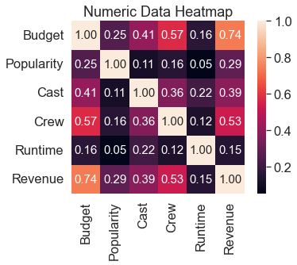

```python
NHMcols = ['Budget', 'Popularity', 'Cast', 'Crew', 'Runtime', 'Revenue']
NHMtmdbdf = tmdbdf[NHMcols]

NHMtmdbdf = NHMtmdbdf.dropna().astype('float')

Ncm = np.corrcoef(NHMtmdbdf.values, rowvar=0)

sns.set(font_scale=1.5)
hm = sns.heatmap(Ncm,
    cbar=True,
    annot=True,
    square=True,
    fmt='.2f',
    annot_kws={'size': 15},
    yticklabels=NHMcols,
    xticklabels=NHMcols)
hm.set_title('Numeric Data Heatmap')

plt.show()
```

Here I have visualized the correlation between all numeric values.  
From this can be clearly visible that Budget has the highest correlation just like was seen during iteration 0.  
What is different however is that the popularity has decreased by a quite significant amount, this is a prime example of why increasing the dataset could show new or different information seen as in iteration 0 I was using only half of the movies and the popularity correlation was at more than double it is now.

Furthermore it can be seen that the added Cast and Crew column also have a pretty decent correlation, especially Crew which can be explained by the fact that the amount of crew members matches the budget/scope of the movie, which already has been established has a pretty big correlation.

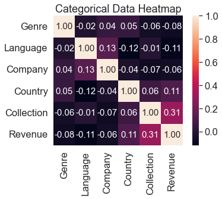

```python
CATcols = ['Genre', 'Language', 'Company', 'Country']
CHMcols = ['Genre', 'Language', 'Company', 'Country', 'Collection', 'Revenue']
CHMtmdbdf = tmdbdf[CHMcols]

CHMtmdbdf[CATcols] = tmdbdf[CATcols].apply(lambda x: x.cat.codes)
# CHMtmdbdf['Collection'].astype('int')
CHMtmdbdf = CHMtmdbdf.dropna().astype('float')

Ccm = np.corrcoef(CHMtmdbdf.values, rowvar=0)

sns.set(font_scale=1.5)
hm = sns.heatmap(Ccm,
    cbar=True,
    annot=True,
    square=True,
    fmt='.2f',
    annot_kws={'size': 15},
    yticklabels=CHMcols,
    xticklabels=CHMcols)
hm.set_title('Categorical Data Heatmap')

plt.show()
```

For the categorical data it can be viewed that most columns do not have any good correlation with revenue, except for Collection, During iteration 0 I also Theorized that movies that are part of a collection would have higher revenue. I think this because production companies would make another movie (for exampel a sequel) in the same movie collection if the movie is successful.

I am however pretty suprised to see no correlation between Genre and Revenue, I was of the assumption that sci-fi, Action and possibly also Horror movies had larger revenues than other genres.

It is also important to take into concideration that getting a correlation from categorical data is not always intuitive and will have to be examined further.

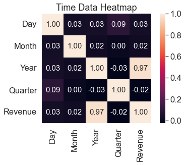

```python
THMcols = ['Day', 'Month', 'Year', 'Quarter', 'Revenue']
THMtmdbdf = tmdbdf[['Revenue']]

THMtmdbdf.loc[:, 'Day'] = tmdbdf['Release'].dt.day
THMtmdbdf.loc[:, 'Month'] = tmdbdf['Release'].dt.month
THMtmdbdf.loc[:, 'Year'] = tmdbdf['Release'].dt.year
THMtmdbdf.loc[:, 'Quarter'] = tmdbdf['Release'].dt.quarter

THMtmdbdf = THMtmdbdf.dropna().astype('float')

Tcm = np.corrcoef(THMtmdbdf.values, rowvar=0)

sns.set(font_scale=1.5)
hm = sns.heatmap(Tcm,
    cbar=True,
    annot=True,
    square=True,
    fmt='.2f',
    annot_kws={'size': 15},
    yticklabels=THMcols,
    xticklabels=THMcols)
hm.set_title('Time Data Heatmap')

plt.show()
```

When visualizing the release period with revenue it can be seen that the releasedate has very little impact on the revenue as also shortly looked into during iteration 0. However what is very noticeable is that the year has an almost perfect correlation with revenue.  
I think this could be because over the years revenue for movies has increased, therefore newer movies have a generally higher revenue, this will have to be further investigated however.

##### Numerical Data

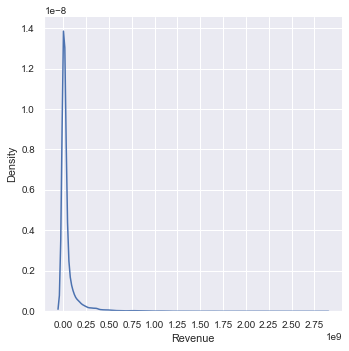

```python
sns.set(font_scale=0.9)
dp = sns.displot(x=tmdbdf['Revenue'], kind="kde")
dp.set(xticks=np.arange(0,3e9,0.25e9))
```

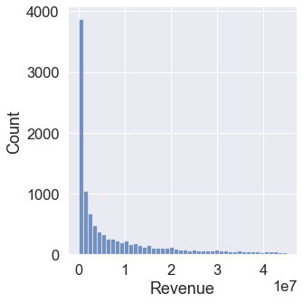

```python
sns.set(font_scale=1.5)
dp = sns.displot(x=tmdbdf[tmdbdf['Revenue'] < 4.5e7]['Revenue'])
dp.set(xticks=np.arange(0,4.5e7,1e7))
```

When zooming in to the range of the 'average' movie revenue, it can be seen that most movies actually earn less than the average given when describing the numerical data (which gave ~4.3e7), showing that indeed the movies that earn up to 2.8 billion dollars more than the average are skewing the average significantly.

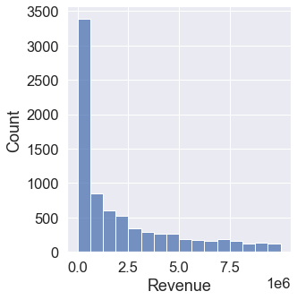

```python
dp = sns.displot(x=tmdbdf[tmdbdf['Revenue'] < 10000000]['Revenue'], bins=16)
dp.set(xticks=np.arange(0,1e7,2.5e6))
```

```python
print(f"Movies with revenue: {len(tmdbdf[~tmdbdf['Revenue'].isnull()])}")
print(f"Median revenue: {tmdbdf['Revenue'].median()}")
```

```
Movies with revenue: 13682
Median revenue: 6033147.5
```

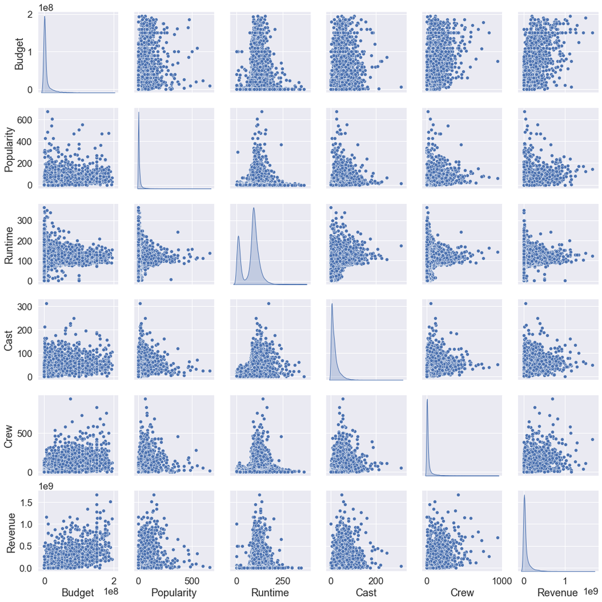

```python
Rtmdbdf = tmdbdf[(tmdbdf['Budget'] < 200000000) & (tmdbdf['Popularity'] < 750) & (tmdbdf['Runtime'] < 400)]
# Limit the variables to less extremes to give a more clear distribution view
sns.pairplot(Rtmdbdf[['Budget', 'Popularity', 'Runtime', 'Cast', 'Crew', 'Revenue']], diag_kind="kde")
```

Previously it was also shown that Budget has a large correlation with Revenue, I will be looking into this feature first compared to revenue.

```python
def LogScatter(x, y):
    xTicks = (len(str(tmdbdf[x].max()))-len(str(tmdbdf[x].min())))+1
    yTicks = (len(str(tmdbdf[y].max()))-len(str(tmdbdf[y].min())))+1
    plt.figure(figsize = (15,10))

    sp = sns.scatterplot(x=tmdbdf[x], y=tmdbdf[y])
    sp.set(xscale="log")
    sp.set(xticks=np.logspace(len(str(tmdbdf[x].min())), len(str(tmdbdf[x].max())), num=xTicks));
    sp.set(yscale="log")
    sp.set(yticks=np.logspace(len(str(tmdbdf[y].min())), len(str(tmdbdf[y].max())), num=yTicks));
```

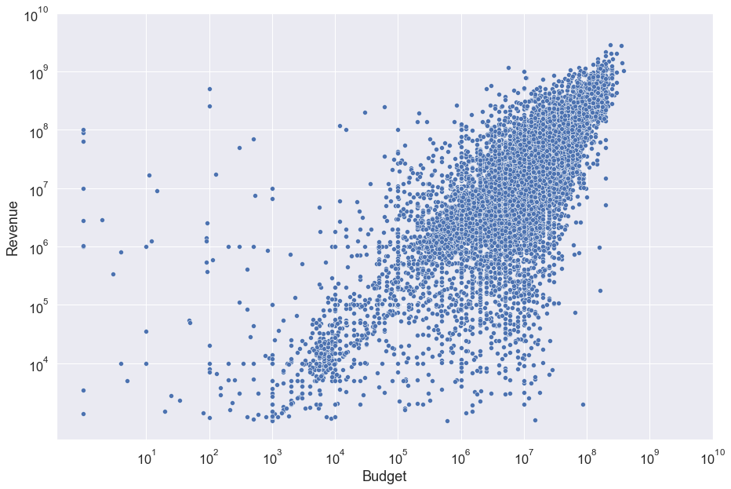

```python
LogScatter('Budget', 'Revenue')
```

When putting both Budget and Revenue on a logarithmic scale, it becomes visible that there indeed seems to be a positive linear correlation between Budget and Revenue starting around 1000 dollars in Budget, which could be explained by the fact that I have not removed any outliers from Budget yet, meaning that possibly just as with Revenue, movies with budgets below 1000 dollars are not valid values.

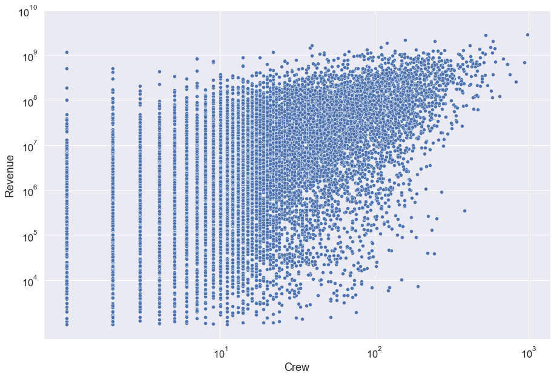

```python
LogScatter('Crew', 'Revenue')
```

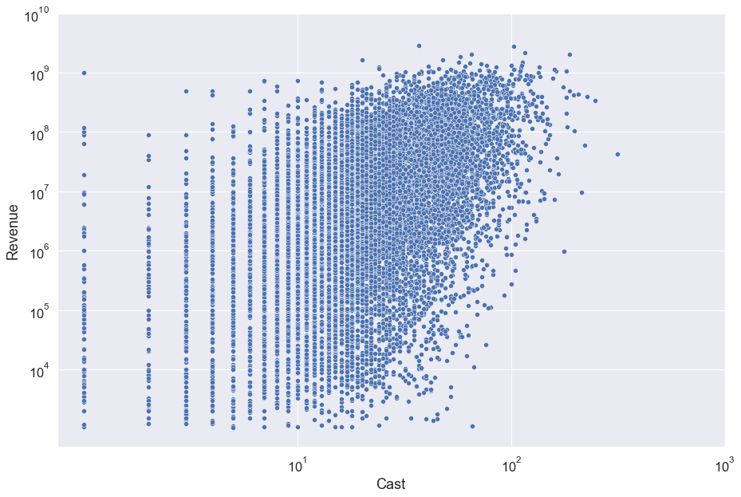

```python
LogScatter('Cast', 'Revenue')
```

From the above graphs can be seen that an increase in Cast and Crew does make movies in general earn higher revenues, this verifies the correlation displayed by the heatmap.

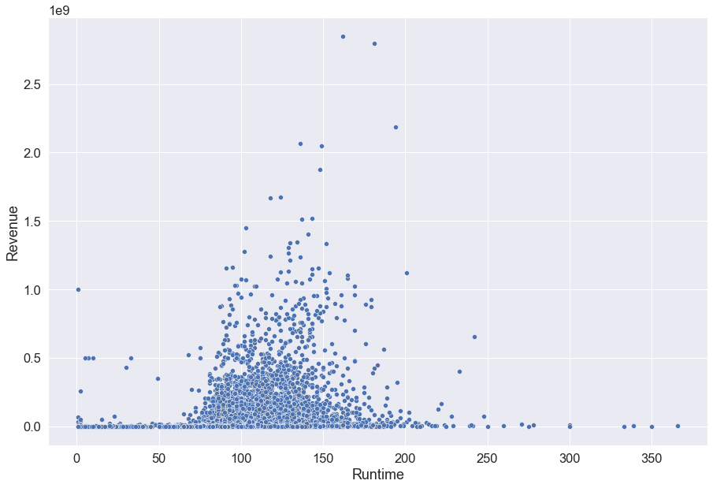

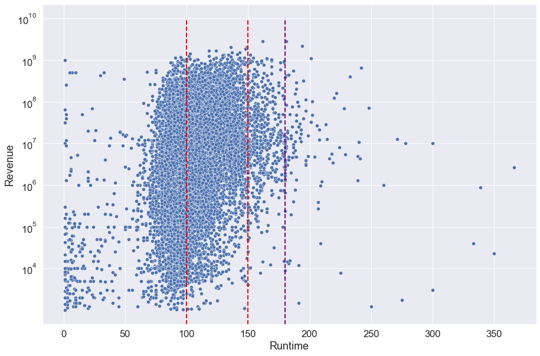

```python
x = 'Runtime'
y = 'Revenue'

plt.figure(figsize = (15,10))
sp = sns.scatterplot(x=tmdbdf[tmdbdf[x] < 400][x], y=tmdbdf[y])
plt.show()

yTicks = (len(str(tmdbdf[y].max()))-len(str(tmdbdf[y].min())))+1
plt.figure(figsize = (15,10))

sp = sns.scatterplot(x=tmdbdf[tmdbdf[x] < 400][x], y=tmdbdf[y])
sp.set(yscale="log")
sp.set(yticks=np.logspace(len(str(tmdbdf[y].min())), len(str(tmdbdf[y].max())), num=yTicks));
plt.vlines(x=[100, 150], ymin=0, ymax=1e10, colors='red', ls='--', lw=2)
plt.vlines(x=180, ymin=0, ymax=1e10, colors='purple', ls='--', lw=2)
plt.show()
```

When looking at the graphs above displaying Runtime against Revenue, it first might seem that there is a nice normaldistribution between the two, which would give a very good correlation. But when looking closer at the axis it can be seen that it is not so clear.  
In the first graph, most data is displayed below 0.5e9, however 0.5e9 is in reality five hundred million dollars, this means that the small 0.5 range in the first graph represents all movies from 0 dollars to 500.000.000 dollars.

This is resolved in the second graph by putting the y axis on a logarithmic scale, here it is clearly visible that most movies fall within a range between 50 and <200 minutes in runtime, with a vast possible range of revenue within them.  
This shows that there is not a good correlation that can be used between Runtime and Revenue.

##### Categorical Data

For categorical data I think looking at the genre could be very interesting to see if the results from the heatmap match up with my own analysis

```
['Comedy', 'Adventure', 'Drama', NaN, 'Family', ..., 'Romance', 'Fantasy', 'War', 'History', 'TV Movie']
Length: 19
Categories (19, object): ['Action', 'Adventure', 'Animation', 'Comedy', ..., 'TV Movie', 'Thriller', 'War', 'Western']
```

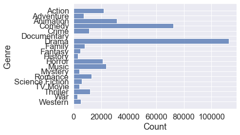

```python
print(tmdbdf['Genre'].unique())
sns.histplot(y = tmdbdf['Genre'])
```

There actually seems to be a pretty nice spread of genres with a clear increase with comedy and drama movies, this could be because drama and comedy are two movie genres that are often combined with other genres.  
Because I only use the first genre a movie is assigned, which should correspond with it's main genre, I also looked if the first genres might be based on alphabetical order or any other specific ordering scheme, but this luckily is not the case.

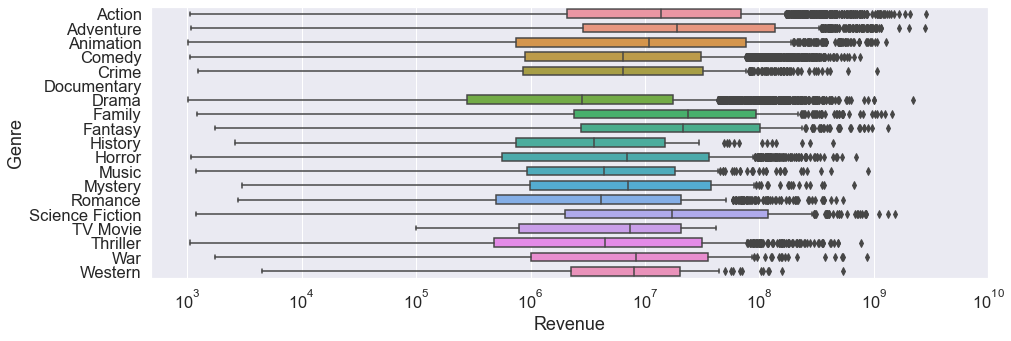

```python
plt.figure(figsize = (15,5))
bp = sns.boxplot(y=tmdbdf['Genre'], x=tmdbdf['Revenue'], width=0.6)
bp.set(xscale="log")
bp.set(xticks=np.logspace(3, 10, num=8));
```

This confirms that there is no real high correlation between Revenue and Genre, seen as all genres earn in the same range of revenue with only a few exceptions.

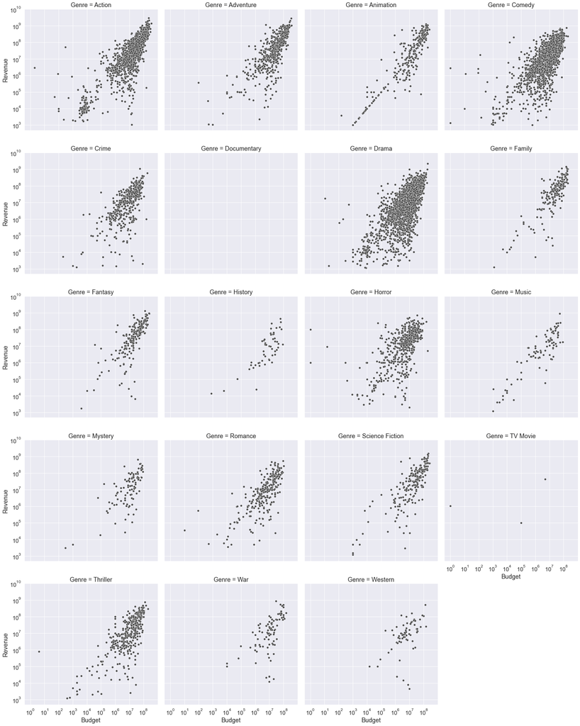

```python
g = sns.FacetGrid(tmdbdf, col="Genre", col_wrap=4, height=6)
g.map(sns.scatterplot, "Budget", "Revenue", color=".3", ci=None)
for ax in g.axes:
    ax.set(xscale="log")
    ax.set(xticks=np.logspace(0, 8, num=9));
    ax.set(yscale="log")
    ax.set(yticks=np.logspace(3, 10, num=8));
```

For more confirmation I also have visualized all different genres with the Revenue and Budget on the axis, here can be seen that all genres indeed follow the same general line, with some minor deviations such as with Horror, where there does seem to be more freedom with the revenue compared to the budget.

In the categorical heatmap it was however shown that being part of a collection can have a correlation with the revenue a movie earns, below this is visualized.

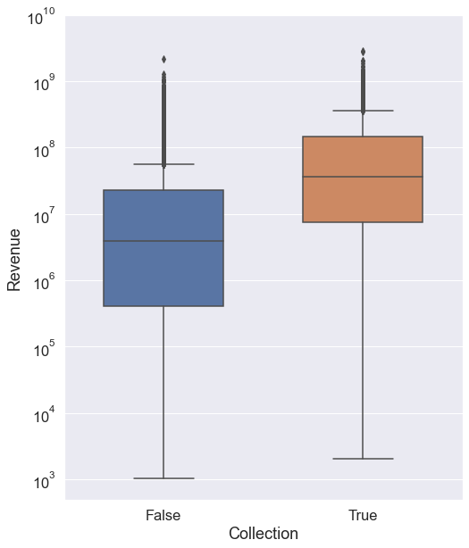

```python
plt.figure(figsize = (8,10))
bp = sns.boxplot(x=tmdbdf['Collection'], y=tmdbdf['Revenue'], width=0.6)
bp.set(yscale="log")
bp.set(yticks=np.logspace(3, 10, num=8));
```

While both kinds of movies seem to have the ability to earn the same amount of revenue, shown by the top outliers, on average movies part of a larger collection do seem to earn more money.

##### Time Data

When creating a heatmap based on time data, I was very suprised to see a very strong correlation between Revenue and Year, so I will be looking more into this statistic.

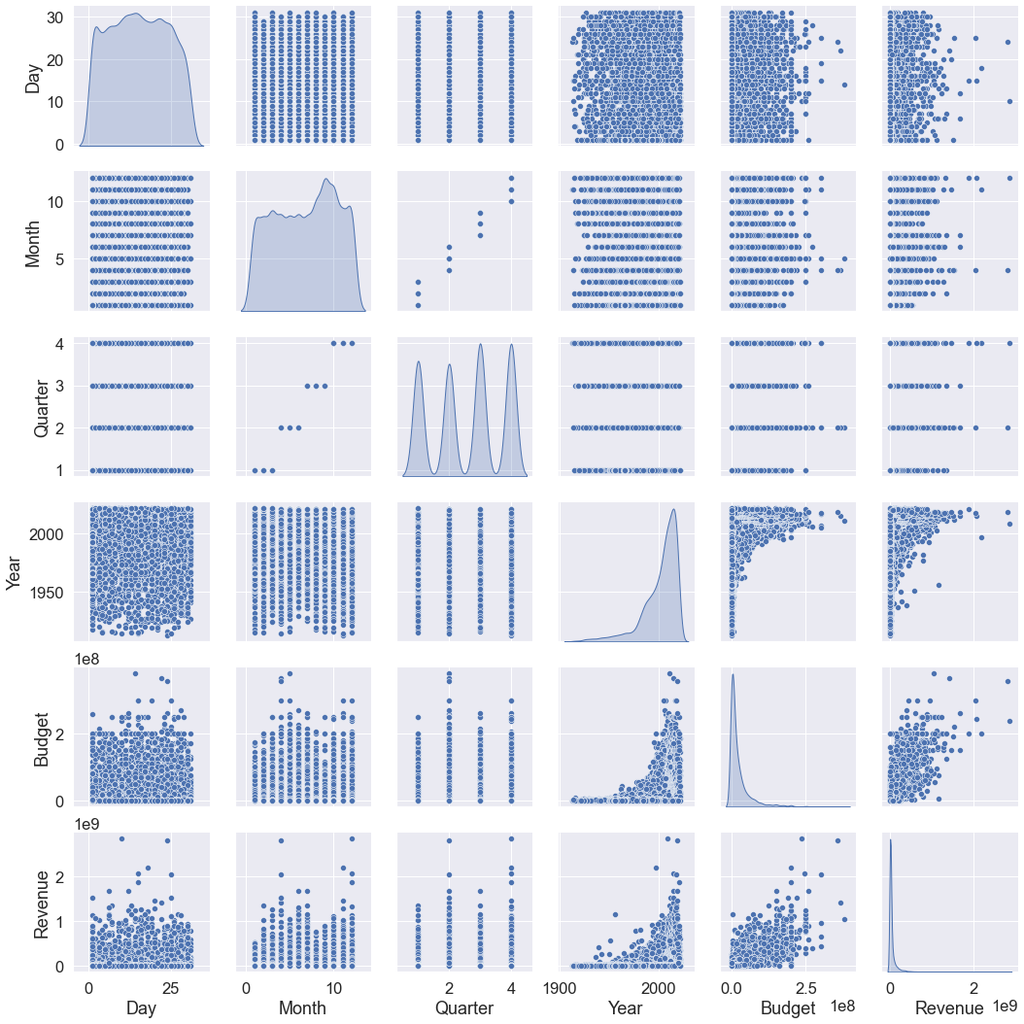

```python
THMtmdbdf.loc[:, 'Budget'] = tmdbdf['Budget']
sns.pairplot(THMtmdbdf[['Day', 'Month', 'Quarter', 'Year', 'Budget', 'Revenue']], diag_kind="kde")
```

When looking at the bottom two rows of this graph, it can be seen that indeed in later years revenue seems to increase, but in those same years budget increases almost identically, this is important because we already know that budget can have a big impact on revenue.  
This confirms my original speculation that a strong correlation can be found between Year and Revenue, because over the years the movie market has become bigger, and therefore can not really be used as an indicator of how successful a movie will be, because all new movies will be released in the most recent year.

#### Conclusion

There are several usefull features in this dataset that can be used for iteration 1 modelling, these features are mainly:

- Budget
- Crew
- Cast
- Collection

with the target being:

- Revenue

And for general rule of thumb it can be stated that genres do not have a major impact on revenue, however: Advenure, Family, Fantasy and Sience Fiction are safer genres for revenue, it should also be considerend that Action can also fit into this list, however the risks of this genre are higher than the others listed.

Furthermore, for runtime, a movie between 100 and 150 minutes in runtime seem to have the highest revenue to risk, while movies up to 180 minutes can be considered, however there seems to be less data here to be given an accurate risk factor.

For data cleaning, there seem to be a lot of outliers. Some outliers such as with the highest revenue are valid, however others mostly focussed budget and runtime seem to be invalid, there also seem to be missing data for the Crew and Cast features that will have to be dealt with. There also seems to be minor issues with the dataset itself, this is caused by the text columns being inproperly standardized causing some records to be wrong.

#### the-numbers Movies

the-numbers dataset will be used to enrich the primary TMDb dataset, therefore the data will have to be made into the same format to allow for merging. It will also be necessary to find good indicators to compare find matching movies from both datasets or even create new movie entries if needed.

```python
tndf = pd.read_csv('Datasets/the-number_movies.csv')
tndf.info()
tndf.head()
```

```
<class 'pandas.core.frame.DataFrame'>
RangeIndex: 6256 entries, 0 to 6255
Data columns (total 6 columns):
 #   Column                 Non-Null Count  Dtype
---  ------                 --------------  -----
 0   web-scraper-order      6256 non-null   object
 1   web-scraper-start-url  6256 non-null   object
 2   Release                6256 non-null   object
 3   Title                  6256 non-null   object
 4   Budget                 6256 non-null   object
 5   Revenue                6256 non-null   object
dtypes: object(6)
memory usage: 293.4+ KB
```

|  | web-scraper-order | web-scraper-start-url | Release | Title | Budget | Revenue |
| --- | --- | --- | --- | --- | --- | --- |
| 0 | 1648116885-1934 | https://www.the-numbers.com/movie/budgets/all/... | Feb 14, 2003 | Gerry | $7,000,000 | $719,699 |
| 1 | 1648116965-5862 | https://www.the-numbers.com/movie/budgets/all/301 | Apr 21, 2011 | Fast Five | $125,000,000 | $630,163,454 |
| 2 | 1648116915-3455 | https://www.the-numbers.com/movie/budgets/all/... | Nov 12, 2015 | By the Sea | $20,000,000 | $3,727,746 |
| 3 | 1648116969-6137 | https://www.the-numbers.com/movie/budgets/all/101 | Jul 14, 2017 | War for the Planet of the Apes | $152,000,000 | $489,592,267 |
| 4 | 1648116915-3361 | https://www.the-numbers.com/movie/budgets/all/... | Nov 3, 1995 | Home for the Holidays | $20,000,000 | $22,119,269 |

the-numbers dataset, scrapes the Release date, Title, Budget and Revenue directly from the website. The scraper also stores the order in which the element on the page was scraped and which page this element originated from.

Firstly web-scraper-order should be a very good index for the dataset, for this only the '-' will have to be removed.  
After that, the Release column which should hold dates has been read as text and should be a datetime dtype.  
Budget and revenue have a dollar sign in front of the entries which can be removed seen as all data up untill now has been stored as dollars, and the ',' seperators can be removed aswell because all values are stored in per dollar (no million, or comma values).

```python
tndf.sort_values('Release').head(10)
```

|  | web-scraper-order | web-scraper-start-url | Release | Title | Budget | Revenue |
| --- | --- | --- | --- | --- | --- | --- |
| 1055 | 1648116861-703 | https://www.the-numbers.com/movie/budgets/all/... | 1968 | Shalako | $1,455,000 | $2,620,000 |
| 519 | 1648116897-2524 | https://www.the-numbers.com/movie/budgets/all/... | 1970 | The Molly Maguires | $11,000,000 | $2,200,000 |
| 4428 | 1648116867-982 | https://www.the-numbers.com/movie/budgets/all/... | 1971 | Escape from the Planet of the Apes | $2,500,000 | $12,300,000 |
| 3186 | 1648116863-799 | https://www.the-numbers.com/movie/budgets/all/... | 1973 | Battle for the Planet of the Apes | $1,800,000 | $8,800,000 |
| 2638 | 1648116897-2504 | https://www.the-numbers.com/movie/budgets/all/... | 1975 | Barry Lyndon | $11,000,000 | $20,169,934 |
| 2026 | 1648116885-1878 | https://www.the-numbers.com/movie/budgets/all/... | 1976 | Logan's Run | $7,000,000 | $25,000,000 |
| 2003 | 1648116873-1309 | https://www.the-numbers.com/movie/budgets/all/... | 1976 | Network | $3,800,000 | $23,689,877 |
| 3017 | 1648116859-558 | https://www.the-numbers.com/movie/budgets/all/... | 1976 | The Blue Bird | $1,200,000 | $887,000 |
| 2878 | 1648116849-99 | https://www.the-numbers.com/movie/budgets/all/... | 1977 | Eraserhead | $100,000 | $7,097,971 |
| 5025 | 1648116855-435 | https://www.the-numbers.com/movie/budgets/all/... | 1977 | Kingdom of the Spiders | $500,000 | $17,000,000 |

Not all movies seem to have a full release date, this will make it harder to cross reference the movie's Release date, and will make it harder to convert the Release to datetimes.

```python
tndf[tndf['Revenue'] == '$0'].head()
```

|  | web-scraper-order | web-scraper-start-url | Release | Title | Budget | Revenue |
| --- | --- | --- | --- | --- | --- | --- |
| 8 | 1648116853-331 | https://www.the-numbers.com/movie/budgets/all/... | Unknown | Pancakes | $400,000 | $0 |
| 33 | 1648116867-1009 | https://www.the-numbers.com/movie/budgets/all/... | Jul 3, 2015 | Stung | $2,500,000 | $0 |
| 48 | 1648116857-549 | https://www.the-numbers.com/movie/budgets/all/... | Unknown | Snitch | $850,000 | $0 |
| 67 | 1648116849-115 | https://www.the-numbers.com/movie/budgets/all/... | Nov 10, 2015 | The Night Visitor | $100,000 | $0 |
| 68 | 1648116853-284 | https://www.the-numbers.com/movie/budgets/all/... | Apr 14, 2015 | Roadside | $500,000 | $0 |

```python
print(f"Missing Revenue: {len(tndf[tndf['Revenue'] == '$0'].index)}")
print(f"Missing Budget: {len(tndf[tndf['Budget'] == '$0'].index)}")
```

```
Missing Revenue: 408
Missing Budget: 0
```

There are also Revenue entries that have missing values, these should be handled properly aswell when changing Budget and Revenue to numerical dtypes.

#### Conclusion

For the dataframe, web-scraper-order can be used as the index, however this should not be of great importance seen as the dataframe will be merged anyway.

Movies will be able to be cross referenced and merged, using the Release when available and Title, in general the-numbers also holds a more accurate count of the Revenue and Budget than TMDb, this means that it will also be worth to validate already existing revenue and budget entries in the TMDb dataframe with this dataframe.

For cleaning, the web-scraper-order column will need it's '-' seperator removed to be able to be used as an index.  
The web-scraper-start-url, will not be usefull seen at only contains scraper/website data.  
The Release column contains dates that will have to be changed into a datetime dtype, however not all rows have a valid formatted date for this.  
The Budget and Revenue columns will need it's dollar signs and ',' characters removed before setting to a numerical dtype. The Revenue column also contains missing values which will have to be cleaned up.

### Data Preparation

#### the-numbers

Because the-numbers will be merged into TMDb, I will be cleaning the-numbers first

The first step will be to prep and set the web-scraper-order as the index of the dataframe.  
After this the Release column should be set as a datetime dtype.  
Lastly the Revenue and Budget columns should be cleaned as made into numerical columns.

```python
import pandas as pd
import numpy as np
import seaborn as sns
import matplotlib.pyplot as plt

print('numpy version:', np.__version__)
print('pandas version:', pd.__version__)
print('seaborn version:', sns.__version__)
```

```
numpy version: 1.20.3
pandas version: 1.3.4
seaborn version: 0.11.2
```

```python
tndf = pd.read_csv('Datasets/the-number_movies.csv')

tndf['web-scraper-order'] = tndf['web-scraper-order'].str.replace('-', '')
# Set index
tndf = tndf.set_index('web-scraper-order')
tndf.index.name = 'Id'

# Select columns to be used
tndf = tndf[['Release', 'Title', 'Revenue', 'Budget']]

# Set Release as date
tndf['Release'] = pd.to_datetime(tndf['Release'],  errors='coerce')
tndf[['Revenue', 'Budget']] = tndf[['Revenue', 'Budget']].replace('\$|,', '', regex=True)
#                                                                 ^ Remove '$' or ','

tndf[['Revenue', 'Budget']] = tndf[['Revenue', 'Budget']].astype('float')
tndf[['Revenue', 'Budget']] = tndf[['Revenue', 'Budget']].replace(0, np.nan, regex=True)

tndf.info()
tndf.head()
```

```
<class 'pandas.core.frame.DataFrame'>
Index: 6256 entries, 16481168851934 to 16481169153429
Data columns (total 4 columns):
 #   Column   Non-Null Count  Dtype
---  ------   --------------  -----
 0   Release  6141 non-null   datetime64[ns]
 1   Title    6256 non-null   object
 2   Revenue  5848 non-null   float64
 3   Budget   6256 non-null   float64
dtypes: datetime64[ns](1), float64(2), object(1)
memory usage: 244.4+ KB
```

| Id | Release | Title | Revenue | Budget |
| --- | --- | --- | --- | --- |
| 16481168851934 | 2003-02-14 | Gerry | 719699.0 | 7000000.0 |
| 16481169655862 | 2011-04-21 | Fast Five | 630163454.0 | 125000000.0 |
| 16481169153455 | 2015-11-12 | By the Sea | 3727746.0 | 20000000.0 |
| 16481169696137 | 2017-07-14 | War for the Planet of the Apes | 489592267.0 | 152000000.0 |
| 16481169153361 | 1995-11-03 | Home for the Holidays | 22119269.0 | 20000000.0 |

All values have now been normalized and cleaned up for merging later.

#### TMDb

```python
import pandas as pd
import numpy as np
import seaborn as sns
import matplotlib.pyplot as plt

print('numpy version:', np.__version__)
print('pandas version:', pd.__version__)
print('seaborn version:', sns.__version__)
```

```
numpy version: 1.20.3
pandas version: 1.3.4
seaborn version: 0.11.2
```

Firstly I will be setting the proper dtypes for all columns, I will also be setting the movieId as the index for the dataframe.

While reading the csv, the collection column will be parsed into an exclusive True/False boolean column, this already deals with any missing data in this column

```python
# Using floats instead of nullable int so that the missing values will be NaN and not <NA> which is harder to handle
tmdbdtype={
    'ImdbId': 'str',
    'Budget': 'float',
    'Genre': 'category',
    'Language': 'category',
    'Popularity': 'float',
    'Company': 'category',
    'Country': 'category',
    'Revenue': 'float',
    'Runtime': 'float',
    'Title': 'str',
    'Cast': 'float',
    'Crew': 'float',
    'Id': 'str'
}

df = pd.read_csv(
    'Datasets/movies.csv',
    sep=',',
    on_bad_lines='skip',
    lineterminator=';',
# Setting line terminator will add newline "\r\n" to the first column so this will have to be removed later
    dtype=tmdbdtype,
    converters={'Collection': lambda x: True if x == 'True' else False})
# Handle boolean values that are NaN instead of false

# Clean up the Id to be used as index
df = df[df['Id'] != '\r\n']
df[['Id']] = df[['Id']].astype('int64')
df = df.set_index('Id')
df = df.replace(0, np.nan)

# Set the datetime
df['Release'] = pd.to_datetime(df['Release'],  errors='coerce')

df.info()
```

```
<class 'pandas.core.frame.DataFrame'>
Int64Index: 679850 entries, 3924 to 952054
Data columns (total 14 columns):
 #   Column      Non-Null Count   Dtype
---  ------      --------------   -----
 0   ImdbId      447108 non-null  object
 1   Collection  679850 non-null  bool
 2   Budget      32488 non-null   float64
 3   Genre       461748 non-null  category
 4   Language    679850 non-null  category
 5   Popularity  679850 non-null  float64
 6   Company     295214 non-null  category
 7   Country     404610 non-null  category
 8   Release     624860 non-null  datetime64[ns]
 9   Revenue     15409 non-null   float64
 10  Runtime     515525 non-null  float64
 11  Title       679844 non-null  object
 12  Cast        454344 non-null  float64
 13  Crew        559981 non-null  float64
dtypes: bool(1), category(4), datetime64[ns](1), float64(6), object(2)
memory usage: 61.0+ MB
```

Note this process can take up a very long time.

```python
# Merging in reverse order: e.g. checking every entry in tmdb dataframe.
# def MergeDF(row):
#     print(row.name)
# # Check if there is a movie match between datasets
#     tnEntry = tndf[tndf['Title'] == row.Title]
#     if (not tnEntry.empty):
# # Handle if there are multiple movies matching the Title
#         for tnIndex in tnEntry.index:
# # Find the specific movie based on release year and month with 1 month margin
#             if (tnEntry.loc[tnIndex].Release.year == row.Release.year and (row.Release.month-1) <= tnEntry.loc[tnIndex].Release.month <= (row.Release.month+1)):
# # Set the averaged Budget and Revenue
#                 row.Budget = np.nanmean([tnEntry.loc[tnIndex].Budget, row.Budget])
#                 row.Revenue = np.nanmean([tnEntry.loc[tnIndex].Revenue, row.Revenue])
#                 df.loc[row.name] = row
#                 break

# df.apply(axis=1, func=MergeDF)
```

```python
def MergeDF(row):
# Check if there is a movie match between datasets
    dfEntry = df[df['Title'] == row.Title]
    if (not dfEntry.empty):
# Handle if there are multiple movies matching the Title
        for dfIndex in dfEntry.index:
# Find the specific movie based on release year and month with 1 month margin
            if (dfEntry.loc[dfIndex].Release.year == row.Release.year and (row.Release.month-1) <= dfEntry.loc[dfIndex].Release.month <= (row.Release.month+1)):
# Set the averaged Budget and Revenue
                record = df.loc[dfIndex]
                record.Budget = np.nanmean([dfEntry.loc[dfIndex].Budget, row.Budget])
                record.Revenue = np.nanmean([dfEntry.loc[dfIndex].Revenue, row.Revenue])
                df.loc[dfIndex] = record
                break

tndf.apply(axis=1, func=MergeDF)
print('Done')
```

```
Done
```

Because Revenue will be the target value, all rows not having a valid Revenue will be removed. Documentaries will also not be included seen as these do not fall into the domain this challenge is focussed on.

As seen during the Data Requirements both mayor outliers on Revenue and Budget seem to end around 1000, so these outliers will be cut off.

```python
df = df[(~df['Revenue'].isnull())]
df = df[df['Genre'] != 'Documentary']
df = df[(df['Budget'] > 1000) & (df['Revenue'] > 1000)]
```

While exploring the data it was discovered that invalid movies will be added to the tmdb database and be removed later by moderators/automated systems. However this process takes time causing the used TMDb bot to get some of these movies before they are removed.

If the movies were gathered more than a day ago, this can be resolved by cross referencing the Id sheet that TMDb releases showing all available movies, if any Id's are missing from the sheet it will be clear that these movies were in some way invalid.

The ID sheet can be download from this link: https://files.tmdb.org/p/exports/movie_ids_MM_DD_YYYY.json.gz, this is the same datasheet the TMDb bot references when gathering the movies. The given json file has been decompressed and added to the datasets directory.

```python
# This step can be skipped if the movies were gathered recently, since the newly added movies have not been verified yet.
import json

movieIds = []
print('Started reading json file')
with open('datasets/movie_ids.json', encoding="utf-8") as f:
    for jsonObj in f:
        idDict = json.loads(jsonObj)
        movieIds.append(idDict['id'])

def ApplyIdMask(row):
    if (row.name not in movieIds):
        print(f"Removing {row.Title}")
        print(f"{row.name}")
        df.drop(row.name, inplace=True)

print('Started cross referencing')
df.apply(axis=1, func=ApplyIdMask)
print('Done')
```

```
Started reading json file
Started cross referencing
Removing Manmadha
76683
Removing The toy beatbox splits
881843
Removing Deadshot's Pizzaland 2
899701
Removing Sex the movie
932122
Removing wrong movie damn
939985
Removing Bingo
942045
Removing Danganronpa: Trigger Happy Havoc
946819
Removing Fan Ji
948150
Done
```

```python
df.info()
```

```
<class 'pandas.core.frame.DataFrame'>
Int64Index: 9714 entries, 5 to 948958
Data columns (total 14 columns):
 #   Column      Non-Null Count  Dtype
---  ------      --------------  -----
 0   ImdbId      9452 non-null   object
 1   Collection  9714 non-null   bool
 2   Budget      9714 non-null   float64
 3   Genre       9513 non-null   category
 4   Language    9714 non-null   category
 5   Popularity  9714 non-null   float64
 6   Company     9154 non-null   category
 7   Country     9321 non-null   category
 8   Release     9564 non-null   datetime64[ns]
 9   Revenue     9714 non-null   float64
 10  Runtime     9498 non-null   float64
 11  Title       9714 non-null   object
 12  Cast        9552 non-null   float64
 13  Crew        9487 non-null   float64
dtypes: bool(1), category(4), datetime64[ns](1), float64(6), object(2)
memory usage: 3.5+ MB
```

```python
df = df[(~df['Crew'].isnull()) & (~df['Cast'].isnull())]
```

Now all missing data should have been dealt with, together with most of the wrong data.  
The last step will be to select the columns that will be used for modelling as described during Data Requirements

```python
# Saving the merged dataframe here for ease of use, merging the two dataframes can take quite long
df.to_csv('Datasets/movies_merged.csv')
```

```python
df = df[['Budget', 'Crew', 'Cast', 'Collection', 'Revenue']]
df.info()
```

```
<class 'pandas.core.frame.DataFrame'>
Int64Index: 9448 entries, 5 to 944002
Data columns (total 5 columns):
 #   Column      Non-Null Count  Dtype
---  ------      --------------  -----
 0   Budget      9448 non-null   float64
 1   Crew        9448 non-null   float64
 2   Cast        9448 non-null   float64
 3   Collection  9448 non-null   bool
 4   Revenue     9448 non-null   float64
dtypes: bool(1), float64(4)
memory usage: 378.3 KB
```

## Predictions

### Preprocessing

#### Model Selection

As discussed earlier in the Analytic Approach for predicting revenue, a form of regression will be used.

However what algorithm to use within regression will be further explored here. For reading up on different kinds of regression I found this [usefull blog article](https://www.analyticsvidhya.com/blog/2022/01/different-types-of-regression-models/) and this [post](https://www.jigsawacademy.com/blogs/data-science/types-of-regression-analysis/).

When looking at the data, all data seems to follow a log-normal distribution, and as seen when normalizing this data using a log function, it can be seen that the features such as Budget follow a pretty clear linear slope when plotted with the target variable, for this reason using linear regression on the log data could give good results.

However Linear regression is very bad at dealing with outliers, which my data contains. For this reason other models such as Ridge, Lasso and Elastic Net regression should be looked into further seen as these could be better for this.  
For this Iteration I will be focussing on using a robust linear regression model, these models are less impacted by outliers, such as: RANSAC or TheilSen, these two models will be used during the Modelling and Evaluation phase.

From my research I also found [Polynomial Regression](https://towardsdatascience.com/polynomial-regression-with-scikit-learn-what-you-should-know-bed9d3296f2) which could be good if the data does not fit a good linear path.  
For another explanation on Polynomial Regression you can also look at this blog post, I also found a very good paper written on [regression methods with log-normal data](https://gupea.ub.gu.se/bitstream/handle/2077/37537/gupea_2077_37537_4.pdf;jsessionid=6A99C3E98C05DA83B5131CFB0E3DB593?sequence=4)

#### Feature Selection

For my features as explored during the Data Understanding I described that;  
Revenue will be the target variable, for features, I will be using: Budget, Crew(size), Cast(size) and Collection(boolean). During my investigation I also found that Genre and Runtime do not have a good correlation with revenue, however recommendations can be made from these seen as there is some relation, especialy with runtime. Because of this I will also be testing the effects of adding Runtime as a feature.

### Modelling

For the modelling phase as described in the Model Selection I will be applying two robust linear regression methods: RANSAC and TheilSen, together with the default Linear regression model, all these models are supplied by [sklearn](https://scikit-learn.org/stable/modules/classes.html#outlier-robust-regressors).

KFold cross-validation will also be used during this modelling phase, to remove possible randomness caused by the test-train split to give a better comparison between models and make it easier to spot possible overfitting.

```python
from sklearn.datasets import make_regression
from sklearn.model_selection import cross_val_score
from sklearn.model_selection import RepeatedKFold
from sklearn.linear_model import LinearRegression
from sklearn.linear_model import RANSACRegressor
from sklearn.linear_model import QuantileRegressor
from sklearn.linear_model import TheilSenRegressor

import numpy as np
import seaborn as sns
import matplotlib.pyplot as plt
import pandas as pd

pd.options.mode.chained_assignment = None  # default='warn'
# Turn off setting value on sliced copy warning, I know what I'm doing!
```

```python
df = pd.read_csv('Datasets/movies_merged.csv')
df = df.set_index('Id')

odf = df
```

I will be creating custom functions to simplify the modelling process, seen as these will be generally the same for all sklearn models.

```python
def FitModel(X, y, model, scoring):
    folds = RepeatedKFold(n_splits=10, n_repeats=5, random_state=0)
    scores = cross_val_score(model, X, y, scoring=scoring, cv=folds, n_jobs=-1)
#                                                                    ^n_jobs=-1 will try and use all processors
    return np.absolute(scores)
#          ^Make scores positive
```

Here I will be testing multiple different regressors, using RepeatedKFold and plotting the different results in a boxplot.

```
Linear 0.618 (std 0.022)
RANSAC 0.578 (std 0.033)
TheilSen 0.609 (std 0.024)
```

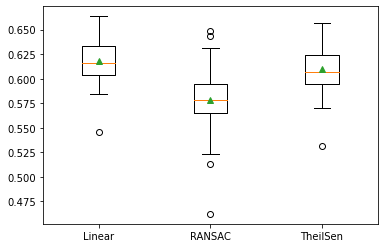

```python
# Selecting features
X = df[['Budget', 'Cast', 'Crew', 'Collection']]
# log numerical features
X.loc[:, X.select_dtypes(include=np.number).columns] = np.log(X[X.select_dtypes(include=np.number).columns])
y = np.log(df['Revenue'])

# Setup
models = dict()
models['Linear'] = LinearRegression()
models['RANSAC'] = RANSACRegressor()
models['TheilSen'] = TheilSenRegressor()
# models['Quantile'] = QuantileRegressor()
#        ^Quantile is very resource intensive After three hours it was still not computed :\
results = dict()

# Fit all models
for name, model in models.items():
    # Evaluate the model
    results[name] = FitModel(X, y, model, 'r2')

    # Summarize progress
    print(f"{name} {results[name].mean():.3f} (std {results[name].std():.3f})")

# plot model performance for comparison
plt.boxplot(results.values(), labels=results.keys(), showmeans=True)
plt.show()
```

Suprisingly Linear regression performed best out of all. Because of this I think it is worth to explore more options, for this I will be testing polynomial linear regression next this should allow the regression line to conform better to the data, in the case that the relation might not be completely linear.

```
Base
Polynomial (degree: 1) 0.594 (std 0.024)
Polynomial (degree: 2) 0.597 (std 0.023)
Polynomial (degree: 3) 0.602 (std 0.022)
Polynomial (degree: 4) 0.600 (std 0.023)
Polynomial (degree: 5) 0.601 (std 0.023)
```

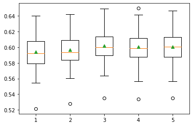

```
Collection
Polynomial (degree: 1) 0.618 (std 0.022)
Polynomial (degree: 2) 0.621 (std 0.022)
Polynomial (degree: 3) 0.622 (std 0.035)
Polynomial (degree: 4) 0.624 (std 0.022)
Polynomial (degree: 5) 0.623 (std 0.022)
```

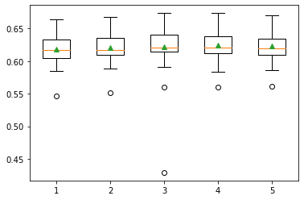

```
Runtime
Polynomial (degree: 1) 0.623 (std 0.022)
Polynomial (degree: 2) 0.626 (std 0.022)
Polynomial (degree: 3) 0.620 (std 0.040)
Polynomial (degree: 4) 0.618 (std 0.180)
Polynomial (degree: 5) 9.348 (std 30.742)
```

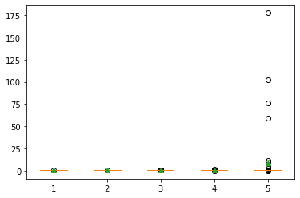

```python
from sklearn.preprocessing import PolynomialFeatures

# Setting features dict to go through
features = dict()
features['Base'] = df[['Budget', 'Cast', 'Crew']]
features['Collection'] = df[['Budget', 'Cast', 'Crew', 'Collection']]

features['Runtime'] = df[['Budget', 'Cast', 'Crew', 'Collection']]


# genreX = df[['Budget', 'Cast', 'Crew', 'Collection']]
# features['Genre'] = pd.concat([genreX, odf['Genre'].str.get_dummies().astype('bool')], axis=1)

# Set target variable
y = np.log(df['Revenue'])

for name, X in features.items():
    print(f"\033[1m{name}\033[0m")

# log numerical features
    X.loc[:, X.select_dtypes(include=np.number).columns] = np.log(X[X.select_dtypes(include=np.number).columns])
# Special case for Runtime, this was one of few features that did not follow a log-normal distribution
    if(name == 'Runtime'):
        X['Runtime'] = odf['Runtime'].fillna(odf['Runtime'].median())

    lr = LinearRegression()

    results = dict()
# Create range of degrees to tune the hyper parameter
    for degree in range(1, 6):
        poly = PolynomialFeatures(degree=degree, include_bias=True)

        pX = poly.fit_transform(X)
        results[degree] = FitModel(pX, y, lr, 'r2')

        print(f"Polynomial (degree: {degree}) {results[degree].mean():.3f} (std {results[degree].std():.3f})")

    plt.boxplot(results.values(), labels=results.keys(), showmeans=True)
#     plt.ylim((0.58, 0.68))
#     plt.xlim(right=5.5)
    plt.show()
```

Above I have gone through and tuned both the features used, to show the impact of boolean value Collection, and numerical Runtime as discussed with Feature Selection and the hyper paramater (in this case degree). I have plotted the results also into a boxplot to have a clearer view of the actual performance of a model.

Below I have also pasted a screenshot of a previous run where the range of degrees was increased, here it is visible that the R^2 and standard deviation suddenly shoot up, showing that overfitting is definitely happening.

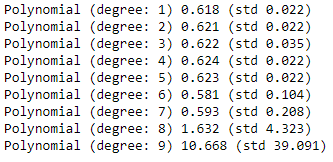

Here is a screenshot of the polynomial regressor running the same feature set as with the Runtime test, but with Genre instead, these results show that Genre really does not improve the model in any significant way and will only cause overfitting. With the only model performing as expected being degree: 1, which is a linear fitline

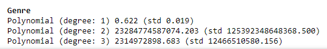

### Evaluation

Before Evaluating my modelling, I did further research into detecting overfitting because I think this could be a serious problem when using polynomial linear regression or when too many features are used and for this I found this [useful article](https://statisticsbyjim.com/regression/overfitting-regression-models/).

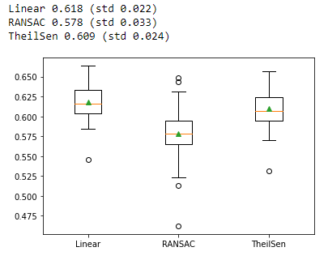

When observing the results above, I started with testing out multiple different models, including linear regression and robust regression models. I ended up running Linear, RANSAC, TheilSen and Quantile regression, however Quantile regression was computing for over 3 hours, at which point I sadly had to abandon this model. From the results gathered from the different models, Linear regression actually gave the best result.

RANSAC most likely performed worse because it will remove a significant amount of 'outliers' decreasing the amount of available datapoints, I could spend extra time tuning the hyper parameters for RANSAC but seen as both other models already performed better, I think this would be better to be left aside. TheilSen regression, performed very similar to Linear regression, it seems that both models came to roughly the same fitline meaning that actually the dataset does not include many outliers that can mess with the modelling.

After finding out that the outliers are not of as much importance as I originally thought, I moved on to also try Polynomial regression, this model creates more freedom in the form of relations between features, because the fitline will not have to be linear.  
During this second phase of modelling I ran the polynomial linear regressor against multiple feature sets and different hyper paramaters to try and find the most optimal combination. Out of this I found that using the Collection feature, did noticeably affect the results in a positive way. It is also very noticeable that with high degree parameter, the model gets very overfitted as seen by the R^2 and standard deviation scores suddenly shooting up.

From the last results I found that Collection is a worth while feature to include, while Genre and Runtime as expected during the Data Understanding are not, it is worth mentioning that while Runtime does increase the overall score of the model slightly I think this is due more to overfitting than there being a good enough correlation.  
For the polynomial regression hyper parameter I have tuned the degree value, with this a higher degree will give the line more freedom to move, generally also increasing the chance of overfitting, for this reason I think a lower degree such as 2 is better than degrees 3-5 while these might still show an increase in R^2.

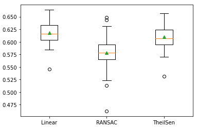

My conclusion based on the modelling done, is that linear regression is a good model to continue with. Polynomial linear regression however should also still be used while taking great caution to not overfit this model. I think choosing a middle path between these two models, using Polynomial Linear Regression with a low degree such as 2 will be the best model to use.

Furthermore for features, I think Budget and Collection are very good features, with Crew and Cast also improving the model overall, but maybe being removed in later iterations in favor for features that more accurately represent the Crew or Cast of a movie.

In future Iteration it will be worth looking more into the specific actors, director/writers, trailers and other marketing.

# Iteration 2

Iteration 2 will be a deeper dive into possible features collected from the TMDb database.

## Provisioning

For Iteration 2, the data sources used will be very similar to Iteration 1.  
This means that in this iteration the-numbers and TMDb will be used in the same way for the data sources as in the previous iteration with no changes.

For a detailed explanation on the used data sources read Iteration 1 - Provisioning

### Data Requirements

- [TMDb](https://www.themoviedb.org/)
- [the-numbers](https://www.the-numbers.com/)

The prediction value will stay as Revenue, this means that all records must contain a revenue value. Furthermore, during Iteration 1 it was discovered that Budget and Collection have great impact on the model's performance so these two features will also be required for any record.

During previous data exploration it was also found that the Crew and Cast have influence on the revenue. I want to explore these aspects of movies further during this iteration, for this I would like more detailed information on the crew such as the director and the cast such as which actors played in the movies.

Furthermore, During last iteration it was discovered that the data imported for the TMDb records was not properly structured, causign records to become currupted or incorrect, for this iteration I want to make sure that no records have skewed, currupted or incorrect data.

### Data Collection

Data Collection is handled the same as during Iteration 1, however some adjustments have been made to the TMDb bot used to gather the movie records from the TMDb database.

These changes revolve around two main points discussed in the Data-Requirements, the need for extra cast and crew data, and the restructuring of the dataset storage.

#### New Data

For the new data, the TMDb bot will now gather 2 new features for the crew, these are the director's name and his popularity score gathered from TMDB, more information on how to popularity score is calculated can be found [here](https://developers.themoviedb.org/3/getting-started/popularity). Furthermore the TMDb bot will now also store 2 extra features for the cast, these will be a string of all actor names seperated by a ',' character and the sum of the actor's popularity score. Two features have also been renamed, these being Crew and Cast, which have been renamed to CrewSize and CastSize to better fit with the newly added features.

The TMDb bot also creates a seperate actors data file which stores all actors with their gender and popularity score linked to the movieId the actor is from as seperate records.

#### Storage Changes

As for how the data is stored differently now, it is important to first look at what caused the problems in the first place.

The delimiter used for the movie csv files before was a ',' character and text data such as movie titles were stored with ' "" ' characters around them to indicate text. However some movie titles contained the same quote character in the title causing text to escape these characters and making these titles incorrect (as only the text inside the first quotes will be considerd for the movie title), this inconsistency can be solved by ignoring the quote characters all together, however this caused another unforseen issue. Some movies contain the ',' character in their text which when loading the csv file will be interpreted as a delimiter thus skewing all the data over by a column and again destroying the data.

These two problems have been solved in this iteration by changign the delimiter to a character not normally used in text: '|' character, also no quote marks will now be put around text fields seen as this is unneeded for a csv file to be interpreted in pandas.

### Data Understanding

Seen as only the TMDb data has been changes since last iteration only this data will be explored, on top of this all features deemed redundant during last iteration will not be explored further and will be ignored where possible.

Title and Release will only be used for cross reference with the-numbers data for this Iteration, while analyzing the title could be of interest in the future.

```python
import pandas as pd
import numpy as np
import seaborn as sns
import matplotlib.pyplot as plt

print('numpy version:', np.__version__)
print('pandas version:', pd.__version__)
print('seaborn version:', sns.__version__)
```

```
numpy version: 1.20.3
pandas version: 1.3.4
seaborn version: 0.11.2
```

```python
dfDtype={
    'Id': 'int64',
    'Budget': 'float',
    'Revenue': 'float',
    'Title': 'str',
    'CastSize': 'float',
    'CrewSize': 'float',
    'Director': 'category',
    'DirectorPopularity': 'float',
    'Cast': 'str',
    'CastPopularity': 'float'
}

cols = [
    'Id',
    'Budget',
    'Revenue',
    'Title',
    'CastSize',
    'CrewSize',
    'Director',
    'DirectorPopularity',
    'Cast',
    'CastPopularity',
    'Release',
]

df = pd.read_csv(
    'Datasets/movies2.csv',
    sep='|',
    usecols=['Id','Budget','Revenue','Title','CastSize','CrewSize','Director','DirectorPopularity','Cast\r','CastPopularity','Release', 'Genre'],
    lineterminator='\n',
    dtype=dfDtype,
    converters={'Collection': lambda x: True if x == 'True' else False},
    parse_dates=['Release'])

# Handle the left over line terminator because pandas does still not allow for multi-character line termination
df['Cast'] = df['Cast\r'].str.replace('\r', '')

# Filter out Documentary movies
df = df[df['Genre'] != 'Documentary']

# Set Id as index and replace all 0 values with NAN
df = df[cols].set_index('Id').replace(0, np.nan)

df.info()
```

```
<class 'pandas.core.frame.DataFrame'>
Int64Index: 590457 entries, 3924 to 965518
Data columns (total 10 columns):
 #   Column              Non-Null Count   Dtype
---  ------              --------------   -----
 0   Budget              30385 non-null   float64
 1   Revenue             15011 non-null   float64
 2   Title               590454 non-null  object
 3   CastSize            411407 non-null  float64
 4   CrewSize            482278 non-null  float64
 5   Director            475638 non-null  category
 6   DirectorPopularity  475636 non-null  float64
 7   Cast                590457 non-null  object
 8   CastPopularity      411406 non-null  float64
 9   Release             539166 non-null  datetime64[ns]
dtypes: category(1), datetime64[ns](1), float64(6), object(2)
memory usage: 52.9+ MB
```

One very important detail that I found out while re-exploring the correlation heatmaps, is that the method used during categorical correlation visualization in iteration 1 was fundamentally flawed. During the creation of this heatmap I converted the categorical data to the numerical keys used internally for categorical columns, however this made the correlation heatmap display a correlation between the numberical value of the key and the revenue.

In the case where the categorical column contained more than 2 columns the correlation would be related to the range of key values I gave and thus not giving a good representation of the possible correlation.

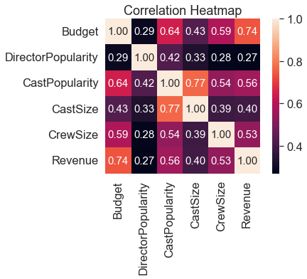

```python
HMcols = ['Budget', 'DirectorPopularity', 'CastPopularity', 'CastSize', 'CrewSize', 'Revenue']
HMdf = df[HMcols].dropna().astype('float')
cm = np.corrcoef(HMdf.values, rowvar=0)

sns.set(font_scale=1.5)
hm = sns.heatmap(cm,
    cbar=True,
    annot=True,
    square=True,
    fmt='.2f',
    annot_kws={'size': 15},
    yticklabels=HMcols,
    xticklabels=HMcols)
hm.set_title('Correlation Heatmap')

plt.show()
```

Above I have created a heatmap that includes the two new numerical features: DirectorPopularity and CastPopularity. As seen CastPopularity seems to have a pretty good correlation with Revenue, indicating that it can could be a good feature to use during modelling.

DirectorPopularity however does not seem to have a good correlation with Revenue meaning that suprisingly the popular directors don't actually make the most earning movies, this also would indicate that people do not consider the director as much when going to a movie compared to something like the actor.

```python
df[['DirectorPopularity', 'CastPopularity', 'Revenue']].describe()
```

|  | DirectorPopularity | CastPopularity | Revenue |
| --- | --- | --- | --- |
| count | 475636.000000 | 411406.000000 | 1.501100e+04 |
| mean | 1.779237 | 31.266338 | 4.475565e+07 |
| std | 2.252707 | 47.933604 | 1.276522e+08 |
| min | 0.600000 | 0.600000 | -1.200000e+01 |
| 25% | 0.600000 | 5.259000 | 2.500000e+05 |
| 50% | 0.980000 | 15.665000 | 4.303351e+06 |
| 75% | 1.978000 | 37.590750 | 2.961895e+07 |
| max | 114.202000 | 1825.747000 | 2.847246e+09 |

```python
df.sort_values('CastPopularity', ascending=False).head(5)
```

| Id | Budget | Revenue | Title | CastSize | CrewSize | Director | DirectorPopularity | Cast | CastPopularity | Release |
| --- | --- | --- | --- | --- | --- | --- | --- | --- | --- | --- |
| 299534 | 356000000.0 | 2.797801e+09 | Avengers: Endgame | 103.0 | 528.0 | Anthony Russo | 7.880 | Robert Downey Jr.,Chris Evans,Mark Ruffalo,Chr... | 1825.747 | 2019-04-24 |
| 541703 | NaN | NaN | Night of 100 Stars | 199.0 | 14.0 | Clark Jones | 0.600 | Jane Alexander,Peter Allen,Steve Allen,June Al... | 1705.452 | 1982-03-08 |
| 299536 | 300000000.0 | 2.046240e+09 | Avengers: Infinity War | 65.0 | 587.0 | Anthony Russo | 7.880 | Robert Downey Jr.,Chris Hemsworth,Mark Ruffalo... | 1316.118 | 2018-04-25 |
| 791373 | 70000000.0 | 6.570000e+08 | Zack Snyder's Justice League | 120.0 | 455.0 | Zack Snyder | 16.668 | Ben Affleck,Henry Cavill,Gal Gadot,Jason Momoa... | 1140.004 | 2021-03-18 |
| 12444 | 250000000.0 | 9.543059e+08 | Harry Potter and the Deathly Hallows: Part 1 | 100.0 | 85.0 | David Yates | 16.292 | Daniel Radcliffe,Rupert Grint,Emma Watson,Hele... | 1105.701 | 2010-10-17 |

When looking more into the CastPopularity it is seen that the spread is actually to be expected, with some outliers being as espected large blockbuster movies made to impress. With one odd duck in the top 5 movies with highest CastPopularity, this being Night of 100 Stars. This was a special event type movie created 1982 with the purpose of being to bring all actors together, including ofcourse the most famous of their time.

The fact that this 'old' movie with actors from that time is still number 2 for the movie with highest CastPopularity indicates that this value is not skewed by new successful movie releases causing massive amounts of people to look up the actors in the movie, thus creating the opposite of what I want where movies with high revenue create a high CastPopularity.

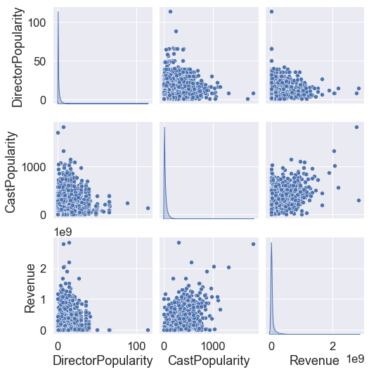

```python
sns.pairplot(df[['DirectorPopularity', 'CastPopularity', 'Revenue']], diag_kind="kde")
```

As seen from the above pairplot, the distribution of the CastPopularity and DirectorPopularity is also log-normal just like the other numerical data explored in iteration 1.

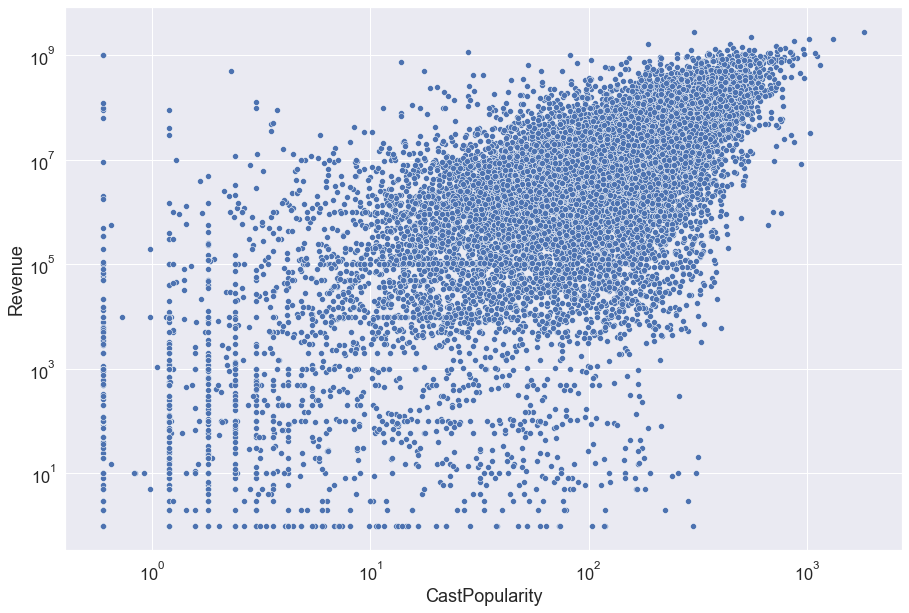

```python
plt.figure(figsize = (15,10))

sp = sns.scatterplot(x=df['CastPopularity'], y=df['Revenue'])
sp.set(xscale="log")
sp.set(yscale="log");
```

There indeed does seem to be correlation between the Revenue and CastPopularity, with especially a steep slope on the higher end of CastPopularity.

This means that indeed having an overal cast that is more popular will actually increase the revenue of the movie.  
While as mentioned before having a popular director does not.

Furthermore, I have also discovered that finding correlation for nominal categorical data is not a good way of approaching these features, seen as the nature of these categorical values can not be put on a scale/range, therefore using indicators for these categorical values as done with the CastPopularity for example is an excelent alternative. This however does not apply to categorical variables with a boolean outcome such as Collection (which could also show why in iteration 1 during the categorical correlation visualization only this feature gave a favorable result).

```python
print(f"Movies: {len(df)}")
print(f"Directos: {len(df['Director'].unique())}")
```

```
Movies: 590457
Directos: 169008
```

Because of the sheer amount of unique Directors (and even more actors), it will not be a good idea to seperate these into seperate boolean columns, and then using these to discover correlation, this would not only increase the computing time massively as already noticed when doing this to Genre, but would also create a lot of possible bias as also explored during the same test with the Genre feature in the modelling phase of iteration 1.

It however would be possible to create a short-list of the top 100 most popular actors for example and use those instead, however I think that the Popularity scoring already does a good job at this, seen as movies with more popular actors will have a higher score.

#### Conclusion

### Data Preparation

## Predictions

### Preprocessing

#### Model Selection

#### Feature Selection

### Modelling

```python
from sklearn.datasets import make_regression
from sklearn.model_selection import cross_val_score
from sklearn.model_selection import RepeatedKFold
from sklearn.linear_model import LinearRegression
from sklearn.linear_model import RANSACRegressor
from sklearn.linear_model import QuantileRegressor
from sklearn.linear_model import TheilSenRegressor

import numpy as np
import seaborn as sns
import matplotlib.pyplot as plt
import pandas as pd
```

### Evaluation

## Delivery

### Collecting

### Documenting

### Reporting